# NYPD Data

pablo

4/29/2023

## Importing the Data

We read the data directly from the below URL, ad display the frist rows to get an idea of the schema.

```r
library(tidyverse)
url_i<-"https://data.cityofnewyork.us/api/views/833y-fsy8/rows.csv?accessType=DOWNLOAD"

d<-read.csv(url_i)
head(d)
```

|  | INCIDENT_KEY | OCCUR_DATE | OCCUR_TIME | BORO | LOC_OF_OCCUR_DESC | PRECINCT | JURISDICTION_CODE | LOC_CLASSFCTN_DESC | LOCATION_DESC | STATISTICAL_MURDER_FLAG | PERP_AGE_GROUP | PERP_SEX | PERP_RACE | VIC_AGE_GROUP | VIC_SEX | VIC_RACE | X_COORD_CD | Y_COORD_CD | Latitude | Longitude | Lon_Lat |
| --- | --- | --- | --- | --- | --- | --- | --- | --- | --- | --- | --- | --- | --- | --- | --- | --- | --- | --- | --- | --- | --- |
| 1 | 228798151 | 05/27/2021 | 21:30:00 | QUEENS |  | 105 | 0 |  |  | false |  |  |  | 18-24 | M | BLACK | 1058925 | 180924.0 | 40.66296 | -73.73084 | POINT (-73.73083868899994 40.662964620000025) |
| 2 | 137471050 | 06/27/2014 | 17:40:00 | BRONX |  | 40 | 0 |  |  | false |  |  |  | 18-24 | M | BLACK | 1005028 | 234516.0 | 40.81035 | -73.92494 | POINT (-73.92494232599995 40.81035186300006) |
| 3 | 147998800 | 11/21/2015 | 03:56:00 | QUEENS |  | 108 | 0 |  |  | true |  |  |  | 25-44 | M | WHITE | 1007668 | 209836.5 | 40.74261 | -73.91549 | POINT (-73.91549174199997 40.74260663300004) |
| 4 | 146837977 | 10/09/2015 | 18:30:00 | BRONX |  | 44 | 0 |  |  | false |  |  |  | <18 | M | WHITE HISPANIC | 1006537 | 244511.1 | 40.83778 | -73.91946 | POINT (-73.91945661499994 40.83778200300003) |
| 5 | 58921844 | 02/19/2009 | 22:58:00 | BRONX |  | 47 | 0 |  |  | true | 25-44 | M | BLACK | 45-64 | M | BLACK | 1024922 | 262189.4 | 40.88624 | -73.85291 | POINT (-73.85290950899997 40.88623791800006) |
| 6 | 219559682 | 10/21/2020 | 21:36:00 | BROOKLYN |  | 81 | 0 |  |  | true |  |  |  | 25-44 | M | BLACK | 1004234 | 186461.7 | 40.67846 | -73.92795 | POINT (-73.92795224099996 40.678456718000064) |

```r
length(d$INCIDENT_KEY)
```

```
## [1] 27312
```

Next we check the class type of each column,

```r
sapply(d,typeof)
```

```
##            INCIDENT_KEY              OCCUR_DATE              OCCUR_TIME
##               "integer"             "character"             "character"
##                    BORO       LOC_OF_OCCUR_DESC                PRECINCT
##             "character"             "character"               "integer"
##       JURISDICTION_CODE      LOC_CLASSFCTN_DESC           LOCATION_DESC
##               "integer"             "character"             "character"
## STATISTICAL_MURDER_FLAG          PERP_AGE_GROUP                PERP_SEX
##             "character"             "character"             "character"
##               PERP_RACE           VIC_AGE_GROUP                 VIC_SEX
##             "character"             "character"             "character"
##                VIC_RACE              X_COORD_CD              Y_COORD_CD
##             "character"                "double"                "double"
##                Latitude               Longitude                 Lon_Lat
##                "double"                "double"             "character"
```

We have to convert the dates from string to a date object

```r
d['OCCUR_DATE2'] <- as.Date(d$OCCUR_DATE,"%m/%d/%Y")
head(d$OCCUR_DATE2)
```

```
## [1] "2021-05-27" "2014-06-27" "2015-11-21" "2015-10-09" "2009-02-19"
## [6] "2020-10-21"
```

We see that most of our variables are categorical, so it is better to expore by using frequenices. We can ignore the coordinates as we won’t conduct a geostatistical analysis.

```r
pct_na<-sapply(d,function(x){sum(is.na(x))/length(x)*100})
names <-names(d)

df<-data.frame(names,pct_na)
df
```

|  | names | pct_na |
| --- | --- | --- |
| INCIDENT_KEY | INCIDENT_KEY | 0.000000000 |
| OCCUR_DATE | OCCUR_DATE | 0.000000000 |
| OCCUR_TIME | OCCUR_TIME | 0.000000000 |
| BORO | BORO | 0.000000000 |
| LOC_OF_OCCUR_DESC | LOC_OF_OCCUR_DESC | 0.000000000 |
| PRECINCT | PRECINCT | 0.000000000 |
| JURISDICTION_CODE | JURISDICTION_CODE | 0.007322789 |
| LOC_CLASSFCTN_DESC | LOC_CLASSFCTN_DESC | 0.000000000 |
| LOCATION_DESC | LOCATION_DESC | 0.000000000 |
| STATISTICAL_MURDER_FLAG | STATISTICAL_MURDER_FLAG | 0.000000000 |

[output cut: 12 more lines]

For the Categorical let’s make a few frequencies

```
##  [1] "OCCUR_DATE"              "OCCUR_TIME"
##  [3] "BORO"                    "LOC_OF_OCCUR_DESC"
##  [5] "LOC_CLASSFCTN_DESC"      "LOCATION_DESC"
##  [7] "STATISTICAL_MURDER_FLAG" "PERP_AGE_GROUP"
##  [9] "PERP_SEX"                "PERP_RACE"
## [11] "VIC_AGE_GROUP"           "VIC_SEX"
## [13] "VIC_RACE"                "Lon_Lat"
```

```
## # A tibble: 5 × 2
##   x                  n
##   <chr>          <dbl>
## 1 BRONX         0.291
## 2 BROOKLYN      0.400
## 3 MANHATTAN     0.131
## 4 QUEENS        0.150
## 5 STATEN ISLAND 0.0284
## # A tibble: 3 × 2
##   x               n
##   <chr>       <dbl>
## 1 ""        0.937
## 2 "INSIDE"  0.00886
## 3 "OUTSIDE" 0.0540
## # A tibble: 10 × 2
##    x                    n
##    <chr>            <dbl>
##  1 ""            0.937
##  2 "COMMERCIAL"  0.00366
##  3 "DWELLING"    0.00465
##  4 "HOUSING"     0.0103
##  5 "OTHER"       0.00114
##  6 "PARKING LOT" 0.000256
##  7 "PLAYGROUND"  0.00110
##  8 "STREET"      0.0404
##  9 "TRANSIT"     0.000549
## 10 "VEHICLE"     0.000842
## # A tibble: 41 × 2
##    x                           n
##    <chr>                   <dbl>
##  1 ""                  0.548
##  2 "(null)"            0.0358
##  3 "ATM"               0.0000366
##  4 "BANK"              0.000110
##  5 "BAR/NIGHT CLUB"    0.0230
##  6 "BEAUTY/NAIL SALON" 0.00410
##  7 "CANDY STORE"       0.000256
##  8 "CHAIN STORE"       0.000183
##  9 "CHECK CASH"        0.0000366
## 10 "CLOTHING BOUTIQUE" 0.000513
```

[output cut: 51 more lines]

```
##   x            n
##   <chr>    <dbl>
## 1 F     0.0957
## 2 M     0.904
## 3 U     0.000403
## # A tibble: 7 × 2
##   x                                     n
##   <chr>                             <dbl>
## 1 AMERICAN INDIAN/ALASKAN NATIVE 0.000366
## 2 ASIAN / PACIFIC ISLANDER       0.0148
## 3 BLACK                          0.712
## 4 BLACK HISPANIC                 0.0969
## 5 UNKNOWN                        0.00242
## 6 WHITE                          0.0256
## 7 WHITE HISPANIC                 0.148
```

```
##   BORO        LOC_OF_OCCUR_DESC LOC_CLASSFCTN_DESC LOCATION_DESC
## x character,5 character,3       character,10       character,41
## n numeric,5   numeric,3         numeric,10         numeric,41
##   STATISTICAL_MURDER_FLAG PERP_AGE_GROUP PERP_SEX    PERP_RACE   VIC_AGE_GROUP
## x character,2             character,11   character,5 character,9 character,7
## n numeric,2               numeric,11     numeric,5   numeric,9   numeric,7
##   VIC_SEX     VIC_RACE
## x character,3 character,7
## n numeric,3   numeric,7
```

1.- We see that LOC_OF_OCCUR_DESC, LOC_CLASSFCTN_DESC have 93% missing so we can’t use those columns. 2.- Sex of the perpetrator is empty for 36%, but it is safe to impute M 3.- Sex of the victim has no missing values and 90% is male.

So we see an obvious pattern, that males are way overrepresented as victims ad pepetrators in this type of violent crime. Which matches our intuition

## Graphical Presentation of frequencies

Lets se the Frequencies Graphically

[output not shown]

[figure not shown]

## Seasonality

Lets group the events by month and see if there are any patterns

| df | n |
| --- | --- |
| 2006-01-01 | 129 |
| 2006-02-01 | 97 |
| 2006-03-01 | 102 |
| 2006-04-01 | 156 |
| 2006-05-01 | 173 |
| 2006-06-01 | 180 |

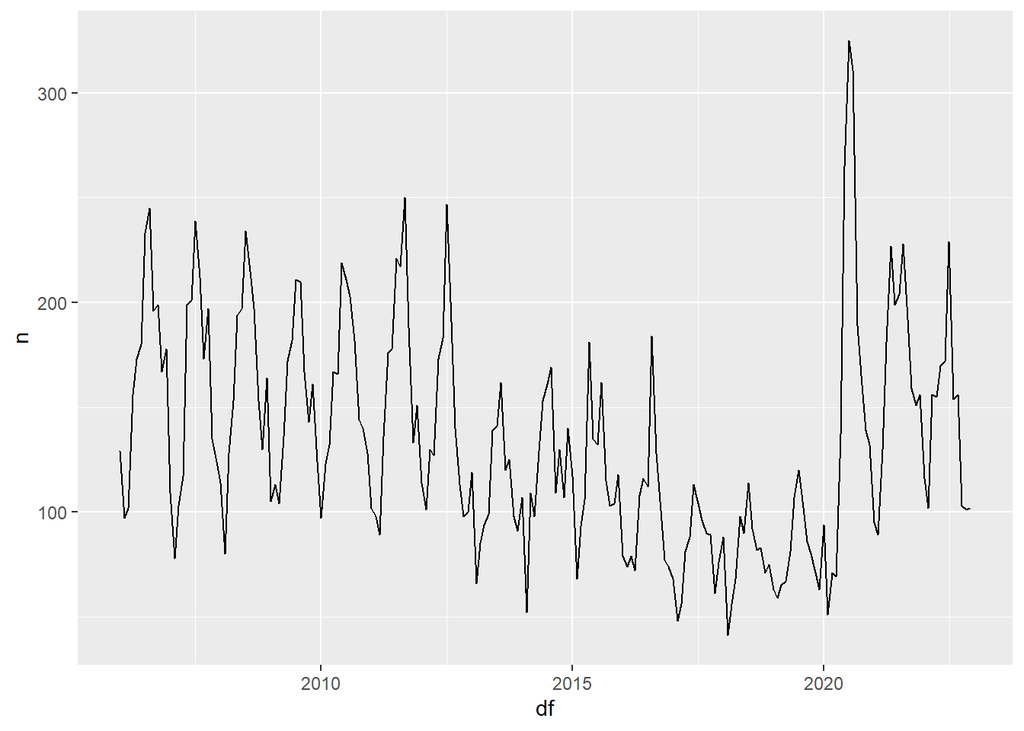

| mth | n |
| --- | --- |
| Jan | 1716 |
| Feb | 1340 |
| Mar | 1688 |
| Apr | 1983 |
| May | 2571 |
| Jun | 2829 |

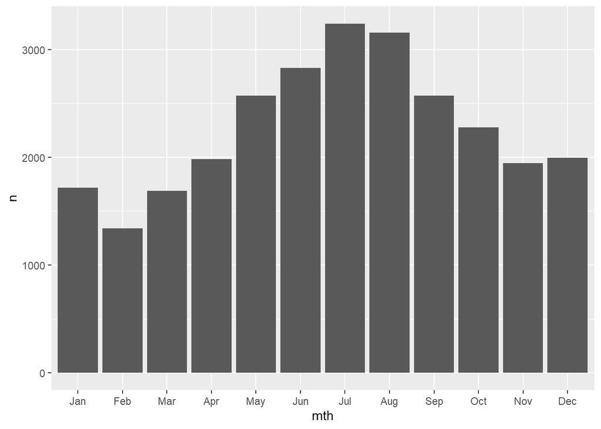

And we see a spike in Summer.

We see a clear Seasonality Patter.

## Test Seasonality

We will try to figure out the seasonality

```r
ts2<- d %>%
  group_by(df ) %>%
  summarise( n = n())
head(ts2)
```

| df | n |
| --- | --- |
| 2006-01-01 | 129 |
| 2006-02-01 | 97 |
| 2006-03-01 | 102 |
| 2006-04-01 | 156 |
| 2006-05-01 | 173 |
| 2006-06-01 | 180 |

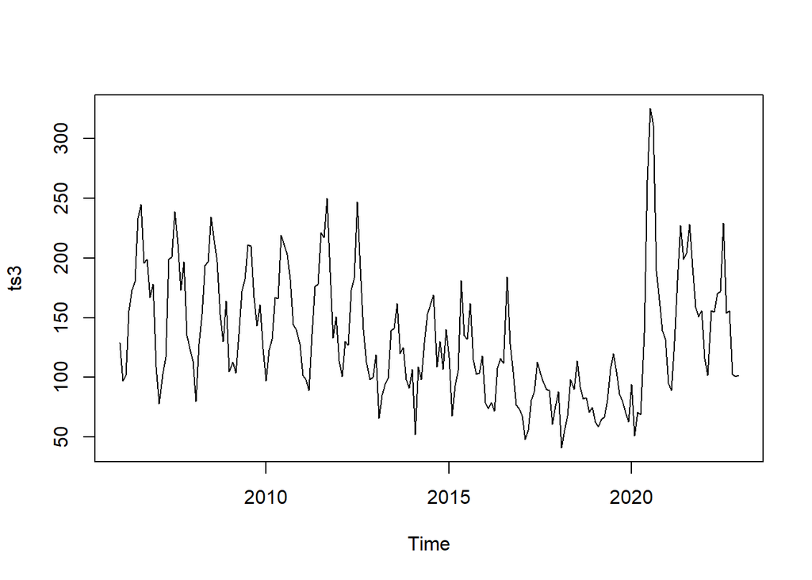

```r
ts3<-ts(ts2$n,frequency = 12,start=c(2006,1))
plot(ts3)
```

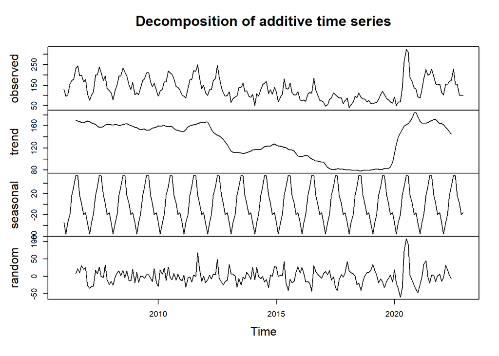

```r
ts_components <- decompose(ts3)
plot(ts_components)
```

```r
summary(ts_components)
```

```
##          Length Class  Mode
## x        204    ts     numeric
## seasonal 204    ts     numeric
## trend    204    ts     numeric
## random   204    ts     numeric
## figure    12    -none- numeric
## type       1    -none- character
```

Notice in trend the the downward slope and the structural breakdown due to COVID which caused asharp increase and brought us back to pre 2010 levels. We see a strong seasonality component

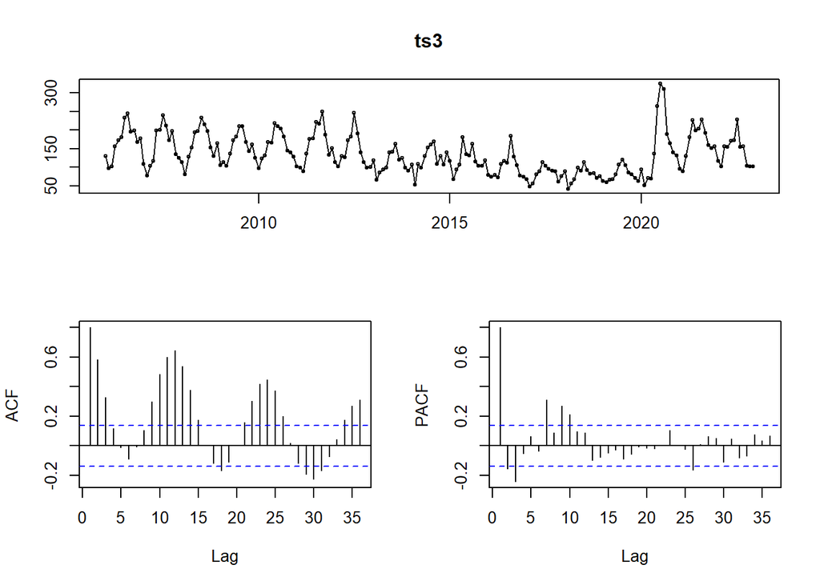

```r
###

library(forecast)
tsdisplay(ts3)
```

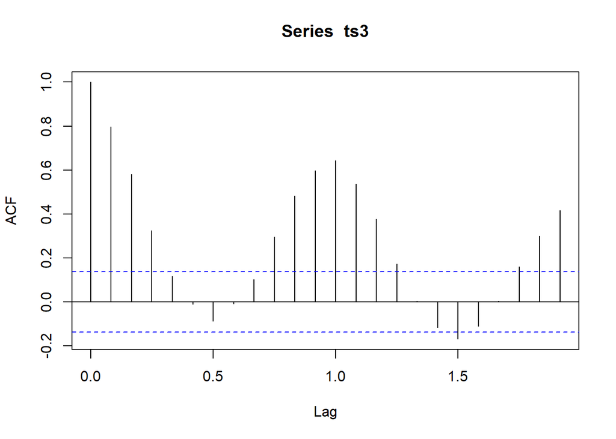

```r
plot(acf(ts3))
```

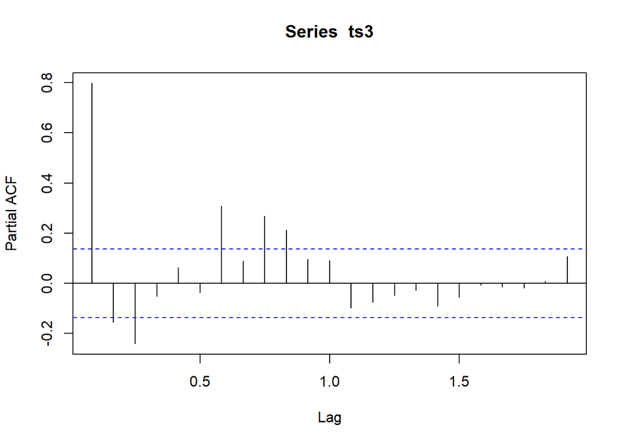

```r
plot(pacf(ts3))
```

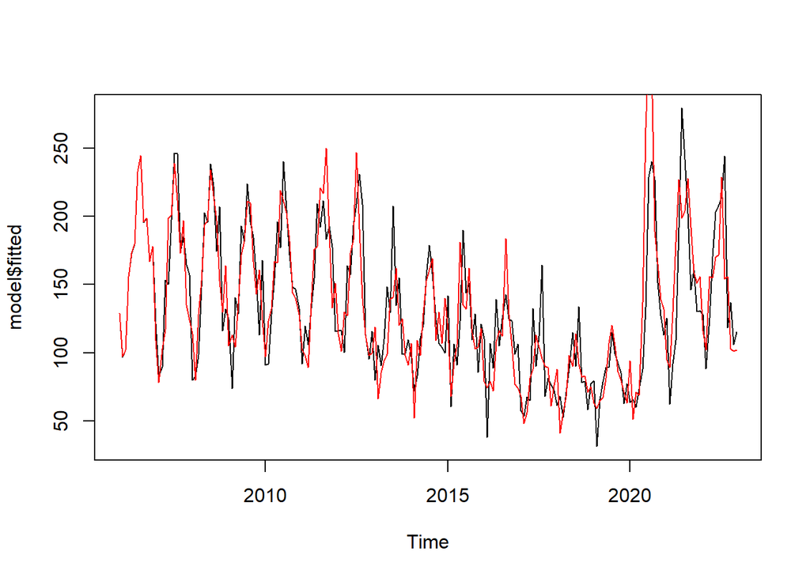

```r
model<-auto.arima(ts3,seasonal = TRUE)
plot(model$fitted)
lines(ts3, col='red')
```

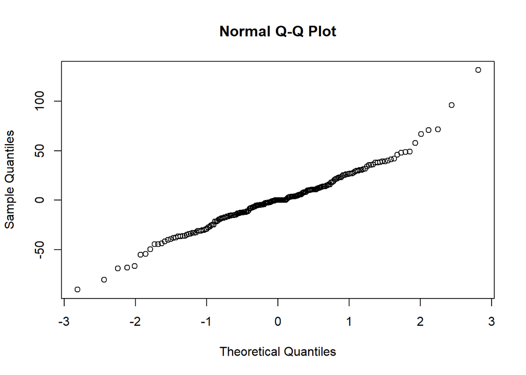

```r
qqnorm(model$residuals)
```

```r
summary(model)
```

```
## Series: ts3
## ARIMA(1,0,0)(1,1,0)[12] with drift
##
## Coefficients:
##          ar1     sar1    drift
##       0.6803  -0.3835  -0.1351
## s.e.  0.0532   0.0689   0.4114
##
## sigma^2 = 917.1:  log likelihood = -927.02
## AIC=1862.04   AICc=1862.25   BIC=1875.07
##
## Training set error measures:
##                       ME     RMSE     MAE       MPE     MAPE     MASE
## Training set -0.02437165 29.14876 21.3069 -2.240472 16.99186 0.767672
##                     ACF1
## Training set -0.08032225
```